# Biscayne Bay Aquatic Preserve

SEACAR Water Quality Analysis

Last compiled on 05 May, 2026

# Indicators

## Nutrients

### Total Nitrogen - Discrete

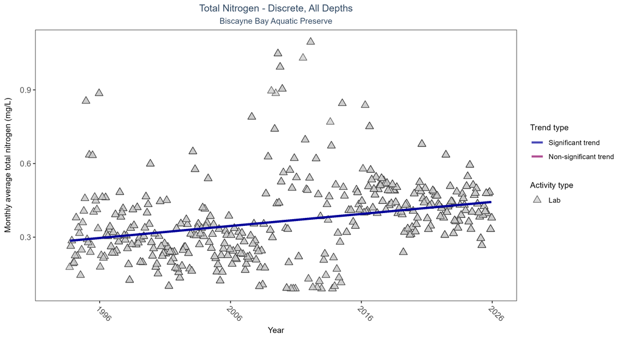

Scatter plot of monthly average total nitrogen over time. If the time series included ten or more years of discrete observations, a significant (blue) or non-significant (magenta) trend line is also shown. Only nitrogen values obtained from laboratory analyses (triangles) are included in the plot.

Seasonal Kendall-Tau Results for - Total Nitrogen

| Activity Type | Statistical Trend | Sample Count | Years with Data | Period of Record | Median Result Value | Tau | Sen Intercept | Sen Slope | P |
| --- | --- | --- | --- | --- | --- | --- | --- | --- | --- |
| Lab | Significantly increasing trend | 9363 | 33 | 1993 - 2025 | 0.335 | 0.23873 | 0.2818 | 0.0049 | 0 |

Monthly average total nitrogen increased by less than 0.01 mg/L per year.

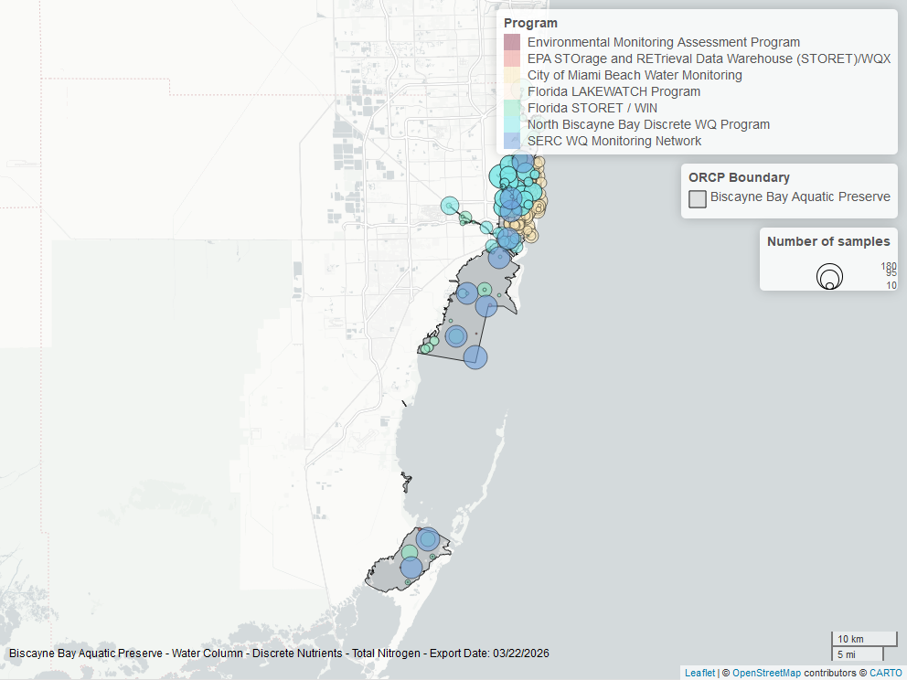

Map showing location of discrete water quality sampling locations within the boundaries of *Biscayne Bay Aquatic Preserve*. The bubble size on the maps above reflect the amount of data available at each sampling site.

### Total Phosphorus - Discrete

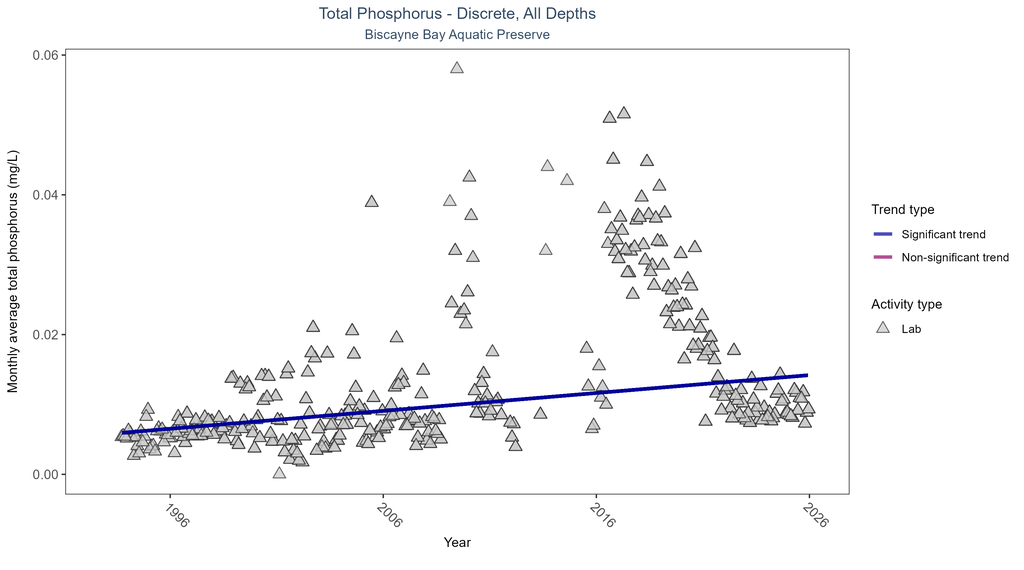

Scatter plot of monthly average total phosphorus over time. If the time series included ten or more years of discrete observations, a significant (blue) or non-significant (magenta) trend line is also shown. Only phosphorus values obtained from laboratory analyses (triangles) are included in the plot.

Seasonal Kendall-Tau Results for - Total Phosphorus

| Activity Type | Statistical Trend | Sample Count | Years with Data | Period of Record | Median Result Value | Tau | Sen Intercept | Sen Slope | P |
| --- | --- | --- | --- | --- | --- | --- | --- | --- | --- |
| Lab | Significantly increasing trend | 9858 | 33 | 1993 - 2025 | 0.009 | 0.37984 | 0.00576 | 0.00026 | 0 |

Monthly average total phosphorus increased by less than 0.01 mg/L per year.

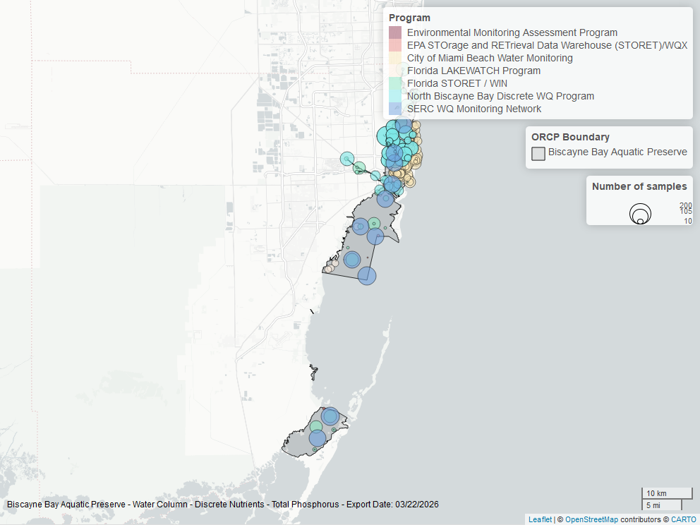

Map showing location of discrete water quality sampling locations within the boundaries of *Biscayne Bay Aquatic Preserve*. The bubble size on the maps above reflect the amount of data available at each sampling site.

## Water Quality

### Dissolved Oxygen - Continuous

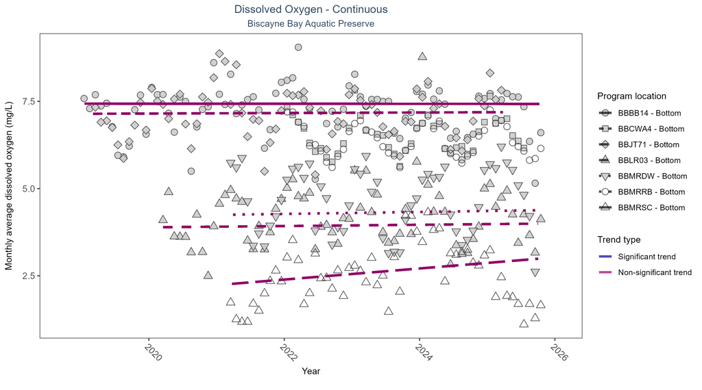

Scatter plot of monthly average dissolved oxygen over time at continuously monitored program locations. Each location is analyzed separately, with significant (blue) or non-significant (magenta) trend lines shown for time series that included five or more years of observations.

Seasonal Kendall-Tau Results - Dissolved Oxygen

| Program Location | Statistical Trend | Sample Count | Years with Data | Period of Record | Median Result Value | Tau | Sen Intercept | Sen Slope | P |
| --- | --- | --- | --- | --- | --- | --- | --- | --- | --- |
| BBBB14 | No significant trend | 209766 | 7 | 2019 - 2025 | 7.2 | -0.01 | 7.43 | 0 | 1 |
| BBCWA4 | Insufficient data to calculate trend | 108422 | 4 | 2022 - 2025 | 6.5 | - | - | - | - |
| BBJT71 | No significant trend | 207039 | 7 | 2019 - 2025 | 7.0 | 0.06 | 7.14 | 0.01 | 0.5599 |
| BBLR03 | No significant trend | 177333 | 6 | 2020 - 2025 | 4.2 | 0.06 | 3.89 | 0.02 | 0.6828 |
| BBMRDW | No significant trend | 150197 | 5 | 2021 - 2025 | 4.7 | 0.1 | 4.25 | 0.03 | 0.58 |
| BBMRRB | Insufficient data to calculate trend | 124787 | 4 | 2022 - 2025 | 6.4 | - | - | - | - |
| BBMRSC | No significant trend | 151445 | 5 | 2021 - 2025 | 2.2 | 0.23 | 2.23 | 0.16 | 0.076 |

No detectable change in monthly average dissolved oxygen was observed at five locations. There was insufficient data to fit a model for two locations.

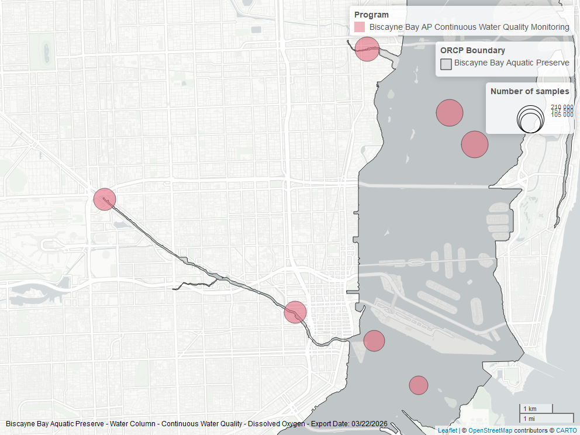

Map showing location of dissolved oxygen continuous water quality sampling locations within the boundaries of *Biscayne Bay Aquatic Preserve*. The bubble size on the maps above reflect the amount of data available at each sampling site.

### Dissolved Oxygen - Discrete

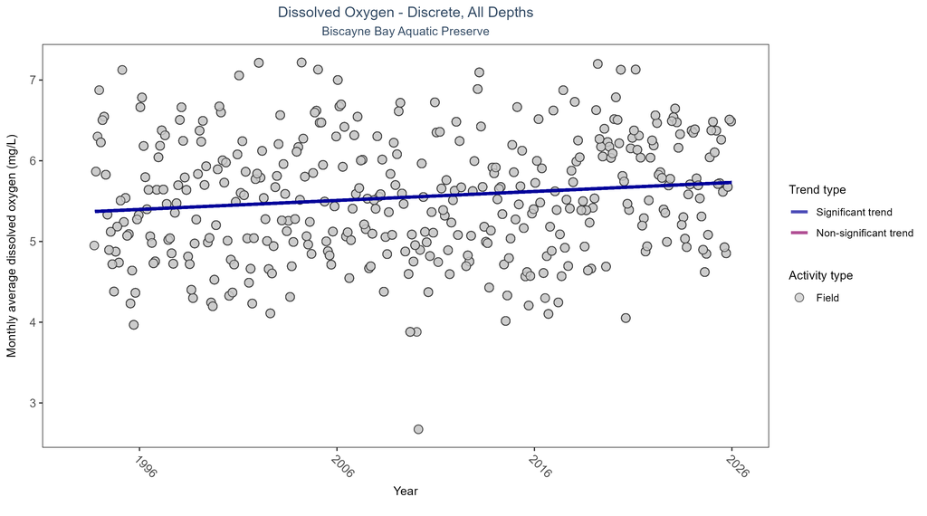

Scatter plot of monthly average dissolved oxygen over time. If the time series included ten or more years of discrete observations, a significant (blue) or non-significant (magenta) trend line is also shown. Only dissolved oxygen values measured in the field (circles) are included in the plot.

Seasonal Kendall-Tau Results for - Dissolved Oxygen

| Activity Type | Statistical Trend | Sample Count | Years with Data | Period of Record | Median Result Value | Tau | Sen Intercept | Sen Slope | P |
| --- | --- | --- | --- | --- | --- | --- | --- | --- | --- |
| Field | Significantly increasing trend | 45505 | 33 | 1993 - 2025 | 5.81 | 0.179 | 5.36365 | 0.01113 | 0 |

Monthly average dissolved oxygen increased by 0.01 mg/L per year.

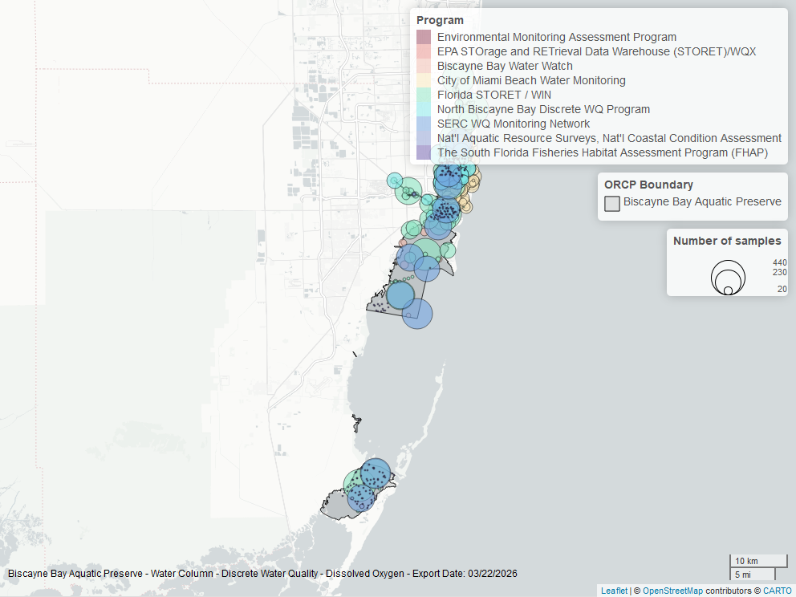

Map showing location of discrete water quality sampling locations within the boundaries of *Biscayne Bay Aquatic Preserve*. The bubble size on the maps above reflect the amount of data available at each sampling site.

### Dissolved Oxygen Saturation - Continuous

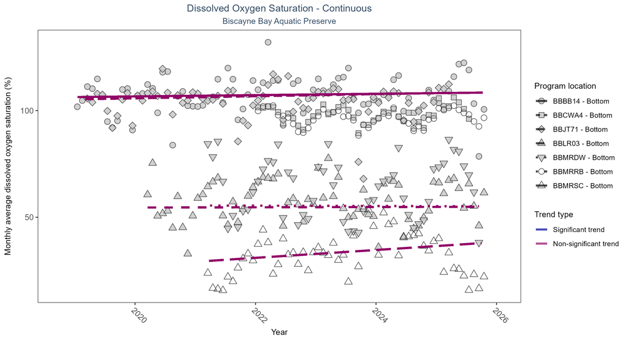

Scatter plot of monthly average dissolved oxygen saturation over time at continuously monitored program locations. Each location is analyzed separately, with significant (blue) or non-significant (magenta) trend lines shown for time series that included five or more years of observations.

Seasonal Kendall-Tau Results - Dissolved Oxygen Saturation

| Program Location | Statistical Trend | Sample Count | Years with Data | Period of Record | Median Result Value | Tau | Sen Intercept | Sen Slope | P |
| --- | --- | --- | --- | --- | --- | --- | --- | --- | --- |
| BBBB14 | No significant trend | 209506 | 7 | 2019 - 2025 | 104.6 | 0.08 | 106.33 | 0.31 | 0.4397 |
| BBCWA4 | Insufficient data to calculate trend | 112145 | 4 | 2022 - 2025 | 97.8 | - | - | - | - |
| BBJT71 | No significant trend | 208190 | 7 | 2019 - 2025 | 102.0 | 0.13 | 105.26 | 0.49 | 0.1852 |
| BBLR03 | No significant trend | 177332 | 6 | 2020 - 2025 | 57.7 | 0.03 | 54.54 | 0.06 | 0.861 |
| BBMRDW | No significant trend | 150198 | 5 | 2021 - 2025 | 62.5 | -0.02 | 55.49 | -0.07 | 0.937 |
| BBMRRB | Insufficient data to calculate trend | 124795 | 4 | 2022 - 2025 | 96.1 | - | - | - | - |
| BBMRSC | No significant trend | 151340 | 5 | 2021 - 2025 | 29.3 | 0.21 | 29.12 | 1.84 | 0.1052 |

No detectable change in monthly average dissolved oxygen saturation was observed at five locations. There was insufficient data to fit a model for two locations.

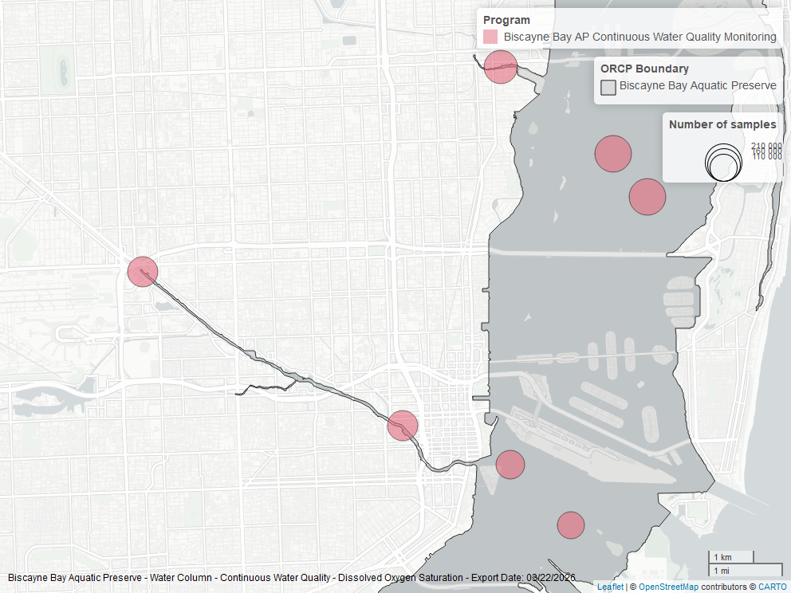

Map showing location of dissolved oxygen saturation continuous water quality sampling locations within the boundaries of *Biscayne Bay Aquatic Preserve*. The bubble size on the maps above reflect the amount of data available at each sampling site.

### Dissolved Oxygen Saturation - Discrete

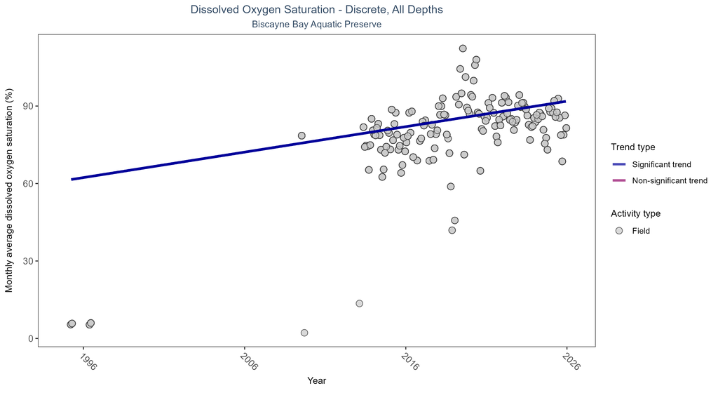

Scatter plot of monthly average dissolved oxygen saturation over time. If the time series included ten or more years of discrete observations, a significant (blue) or non-significant (magenta) trend line is also shown. Only dissolved oxygen saturation values measured in the field (circles) are included in the plot.

Seasonal Kendall-Tau Results for - Dissolved Oxygen Saturation

| Activity Type | Statistical Trend | Sample Count | Years with Data | Period of Record | Median Result Value | Tau | Sen Intercept | Sen Slope | P |
| --- | --- | --- | --- | --- | --- | --- | --- | --- | --- |
| Field | Significantly increasing trend | 15093 | 16 | 1995 - 2025 | 88.7 | 0.38467 | 61.31281 | 0.9861 | 0 |

Monthly average dissolved oxygen saturation increased by 0.99% per year.

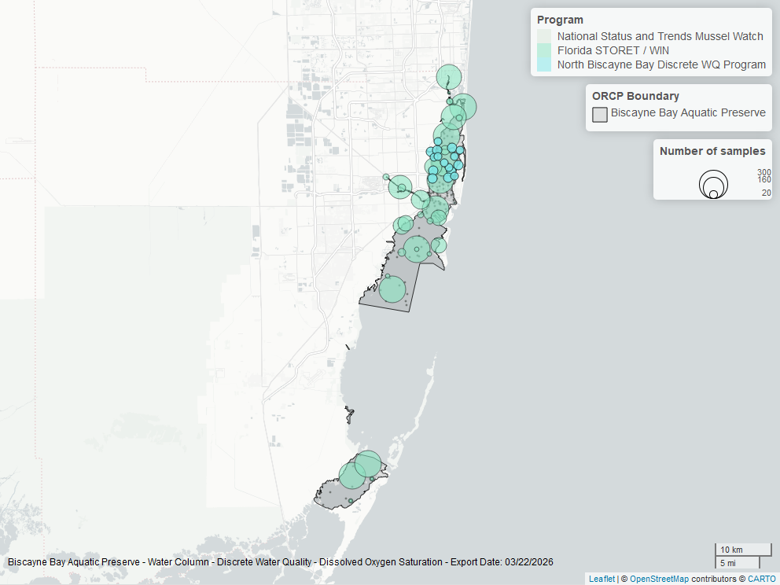

Map showing location of discrete water quality sampling locations within the boundaries of *Biscayne Bay Aquatic Preserve*. The bubble size on the maps above reflect the amount of data available at each sampling site.

### Salinity - Discrete

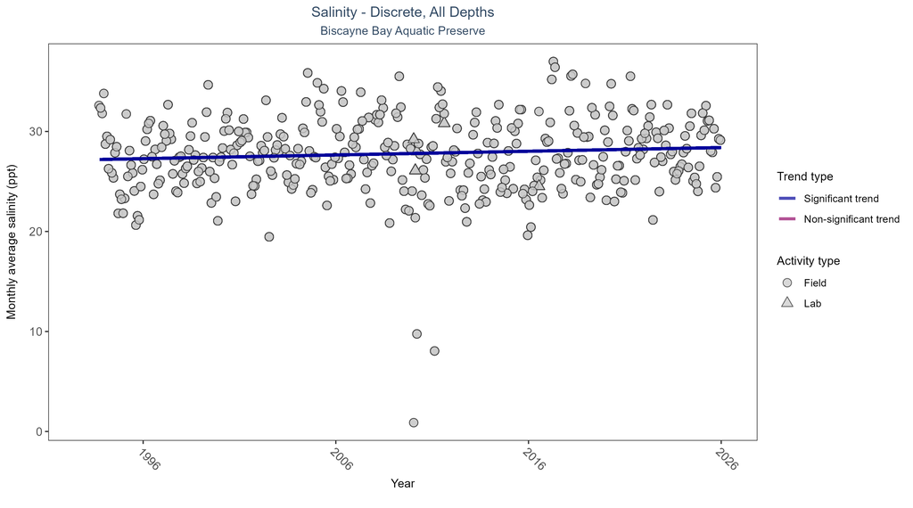

Scatter plot of monthly average salinity over time. If the time series included ten or more years of discrete observations, significant (blue) or non-significant (magenta) trend lines are also shown. Discrete salinity values derived from grab samples analyzed in the field (circles) or the laboratory (triangles) are both included in the plot.

Seasonal Kendall-Tau Results for - Salinity

| Activity Type | Statistical Trend | Sample Count | Years with Data | Period of Record | Median Result Value | Tau | Sen Intercept | Sen Slope | P |
| --- | --- | --- | --- | --- | --- | --- | --- | --- | --- |
| All | Significantly increasing trend | 50529 | 33 | 1993 - 2025 | 31.4 | 0.089 | 27.16942 | 0.03703 | 0.013 |

Monthly average salinity increased by 0.04 ppt per year.

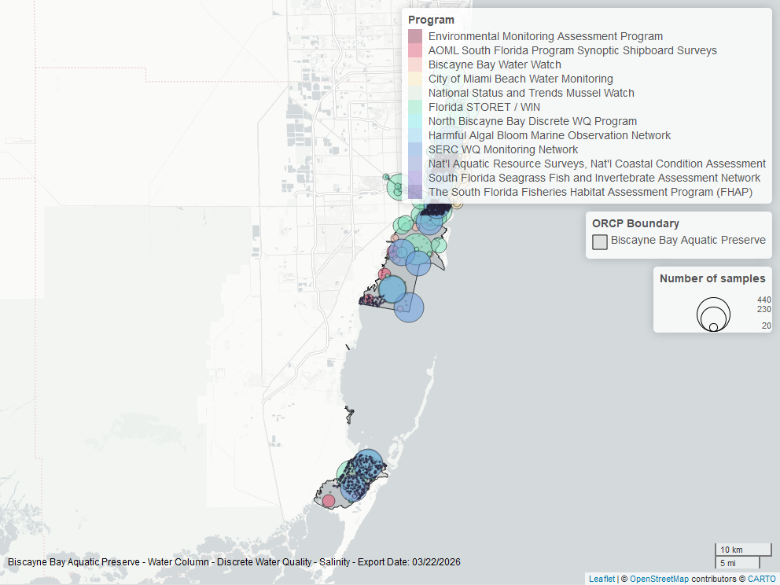

Map showing location of discrete water quality sampling locations within the boundaries of *Biscayne Bay Aquatic Preserve*. The bubble size on the maps above reflect the amount of data available at each sampling site.

### Salinity - Continuous

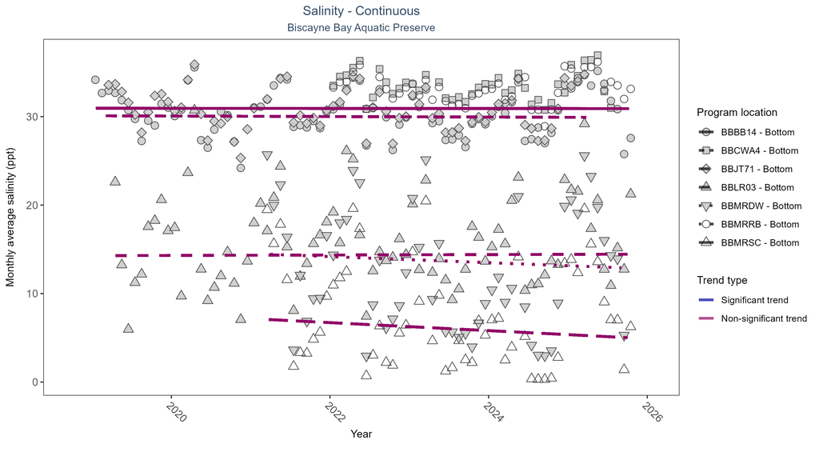

Scatter plot of monthly average salinity over time at continuously monitored program locations. Each location is analyzed separately, with significant (blue) or non-significant (magenta) trend lines shown for time series that included five or more years of observations.

Seasonal Kendall-Tau Results - Salinity

| Program Location | Statistical Trend | Sample Count | Years with Data | Period of Record | Median Result Value | Tau | Sen Intercept | Sen Slope | P |
| --- | --- | --- | --- | --- | --- | --- | --- | --- | --- |
| BBBB14 | No significant trend | 199380 | 7 | 2019 - 2025 | 30.6 | -0.01 | 30.94 | -0.01 | 1 |
| BBCWA4 | Insufficient data to calculate trend | 106537 | 4 | 2022 - 2025 | 33.6 | - | - | - | - |
| BBJT71 | No significant trend | 193275 | 7 | 2019 - 2025 | 31.0 | -0.02 | 30.1 | -0.03 | 0.8694 |
| BBLR03 | No significant trend | 197528 | 7 | 2019 - 2025 | 18.0 | 0.02 | 14.29 | 0.02 | 0.9625 |
| BBMRDW | No significant trend | 146988 | 5 | 2021 - 2025 | 10.9 | -0.17 | 14.52 | -0.34 | 0.2357 |
| BBMRRB | Insufficient data to calculate trend | 124795 | 4 | 2022 - 2025 | 33.3 | - | - | - | - |
| BBMRSC | No significant trend | 153400 | 5 | 2021 - 2025 | 5.1 | -0.13 | 7.17 | -0.45 | 0.3159 |

No detectable change in monthly average salinity was observed at five locations. There was insufficient data to fit a model for two locations.

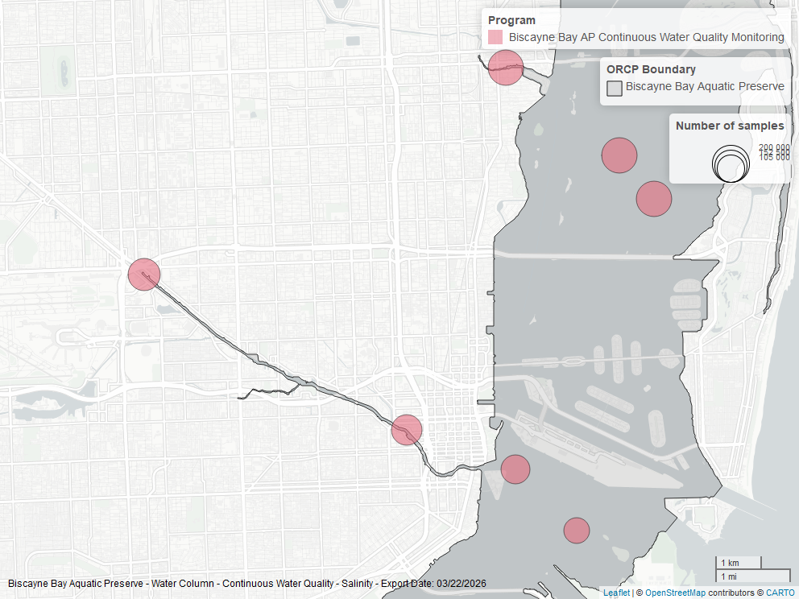

Map showing location of salinity continuous water quality sampling locations within the boundaries of *Biscayne Bay Aquatic Preserve*. The bubble size on the maps above reflect the amount of data available at each sampling site.

### Water Temperature - Continuous

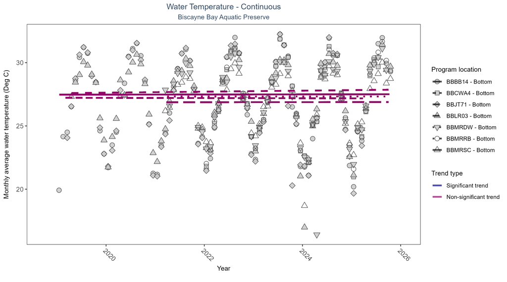

Scatter plot of monthly average water temperature over time at continuously monitored program locations. Each location is analyzed separately, with significant (blue) or non-significant (magenta) trend lines shown for time series that included five or more years of observations.

Seasonal Kendall-Tau Results - Water Temperature

| Program Location | Statistical Trend | Sample Count | Years with Data | Period of Record | Median Result Value | Tau | Sen Intercept | Sen Slope | P |
| --- | --- | --- | --- | --- | --- | --- | --- | --- | --- |
| BBBB14 | No significant trend | 209878 | 7 | 2019 - 2025 | 27.3 | 0.02 | 27.47 | 0 | 0.8915 |
| BBCWA4 | Insufficient data to calculate trend | 113090 | 4 | 2022 - 2025 | 27.1 | - | - | - | - |
| BBJT71 | No significant trend | 208542 | 7 | 2019 - 2025 | 27.1 | -0.03 | 27.22 | -0.01 | 0.8737 |
| BBLR03 | No significant trend | 206286 | 7 | 2019 - 2025 | 27.9 | 0.04 | 27.59 | 0.04 | 0.6721 |
| BBMRDW | No significant trend | 150209 | 5 | 2021 - 2025 | 27.6 | -0.03 | 27.32 | 0 | 1 |
| BBMRRB | Insufficient data to calculate trend | 125603 | 4 | 2022 - 2025 | 27.3 | - | - | - | - |
| BBMRSC | No significant trend | 154183 | 5 | 2021 - 2025 | 27.3 | -0.02 | 26.87 | 0 | 1 |

No detectable change in monthly average water temperature was observed at five locations. There was insufficient data to fit a model for two locations.

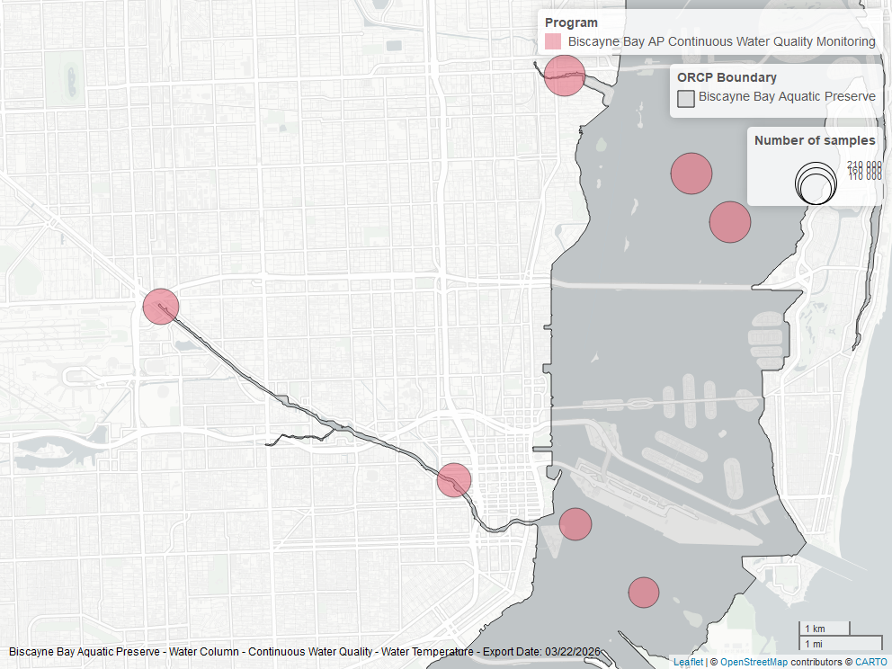

Map showing location of water temperature continuous water quality sampling locations within the boundaries of *Biscayne Bay Aquatic Preserve*. The bubble size on the maps above reflect the amount of data available at each sampling site.

### Water Temperature - Discrete

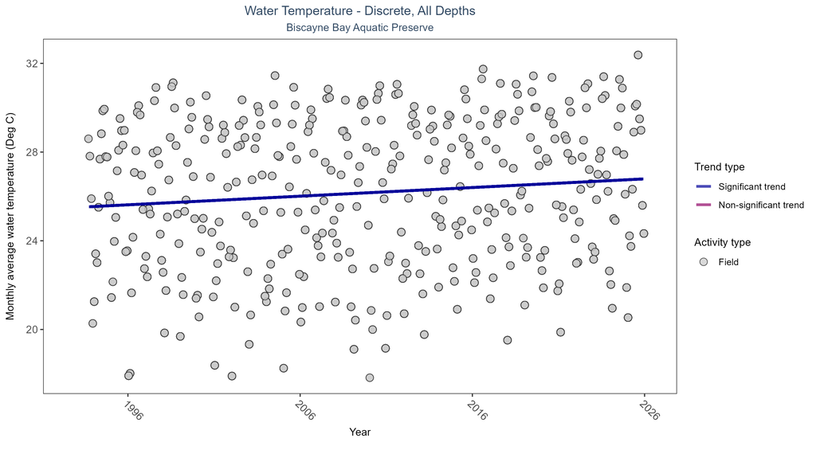

Scatter plot of monthly average water temperature over time. If the time series included ten or more years of discrete observations, a significant (blue) or non-significant (magenta) trend line is also shown. Only water temperature measurements taken in the field (circles) are included in the plot.

Seasonal Kendall-Tau Results for - Water Temperature

| Activity Type | Statistical Trend | Sample Count | Years with Data | Period of Record | Median Result Value | Tau | Sen Intercept | Sen Slope | P |
| --- | --- | --- | --- | --- | --- | --- | --- | --- | --- |
| Field | Significantly increasing trend | 50728 | 33 | 1993 - 2025 | 26.63 | 0.22766 | 25.50481 | 0.03897 | 0 |

Monthly average water temperature increased by 0.04°C per year.

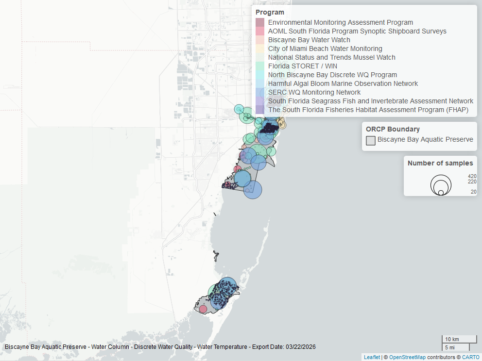

Map showing location of discrete water quality sampling locations within the boundaries of *Biscayne Bay Aquatic Preserve*. The bubble size on the maps above reflect the amount of data available at each sampling site.

### pH - Continuous

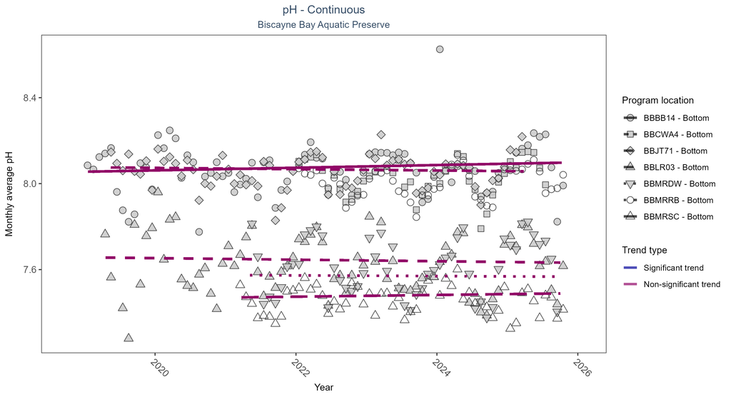

Scatter plot of monthly average pH over time at continuously monitored program locations. Each location is analyzed separately, with significant (blue) or non-significant (magenta) trend lines shown for time series that included five or more years of observations.

Seasonal Kendall-Tau Results - pH

| Program Location | Statistical Trend | Sample Count | Years with Data | Period of Record | Median Result Value | Tau | Sen Intercept | Sen Slope | P |
| --- | --- | --- | --- | --- | --- | --- | --- | --- | --- |
| BBBB14 | No significant trend | 205693 | 7 | 2019 - 2025 | 8.1 | 0.1 | 8.06 | 0.01 | 0.3398 |
| BBCWA4 | Insufficient data to calculate trend | 112102 | 4 | 2022 - 2025 | 8.0 | - | - | - | - |
| BBJT71 | No significant trend | 195449 | 7 | 2019 - 2025 | 8.1 | -0.07 | 8.08 | 0 | 0.5078 |
| BBLR03 | No significant trend | 195530 | 7 | 2019 - 2025 | 7.6 | -0.05 | 7.66 | 0 | 0.6665 |
| BBMRDW | No significant trend | 145249 | 5 | 2021 - 2025 | 7.6 | -0.03 | 7.57 | 0 | 0.9336 |
| BBMRRB | Insufficient data to calculate trend | 124839 | 4 | 2022 - 2025 | 8.0 | - | - | - | - |
| BBMRSC | No significant trend | 150527 | 5 | 2021 - 2025 | 7.4 | 0.03 | 7.47 | 0 | 0.6997 |

No detectable change in monthly average pH was observed at five locations. There was insufficient data to fit a model for two locations.

[figure not shown]

Map showing location of ph continuous water quality sampling locations within the boundaries of *Biscayne Bay Aquatic Preserve*. The bubble size on the maps above reflect the amount of data available at each sampling site.

### pH - Discrete

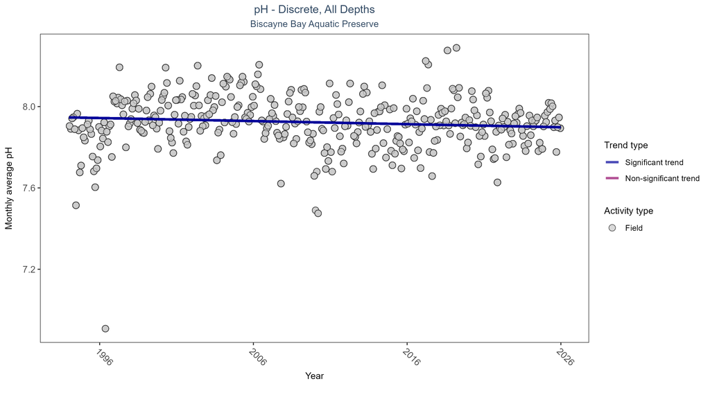

Scatter plot of monthly average pH over time. If the time series included ten or more years of discrete observations, a significant (blue) or non-significant (magenta) trend line is also shown. Only pH values measured in the field (circles) are included in the plot.

Seasonal Kendall-Tau Results for - pH

| Activity Type | Statistical Trend | Sample Count | Years with Data | Period of Record | Median Result Value | Tau | Sen Intercept | Sen Slope | P |
| --- | --- | --- | --- | --- | --- | --- | --- | --- | --- |
| Field | Significantly decreasing trend | 43873 | 32 | 1994 - 2025 | 7.98 | -0.10437 | 7.94675 | -0.00151 | 0.0038 |

Monthly average pH decreased by less than 0.01 pH units per year.

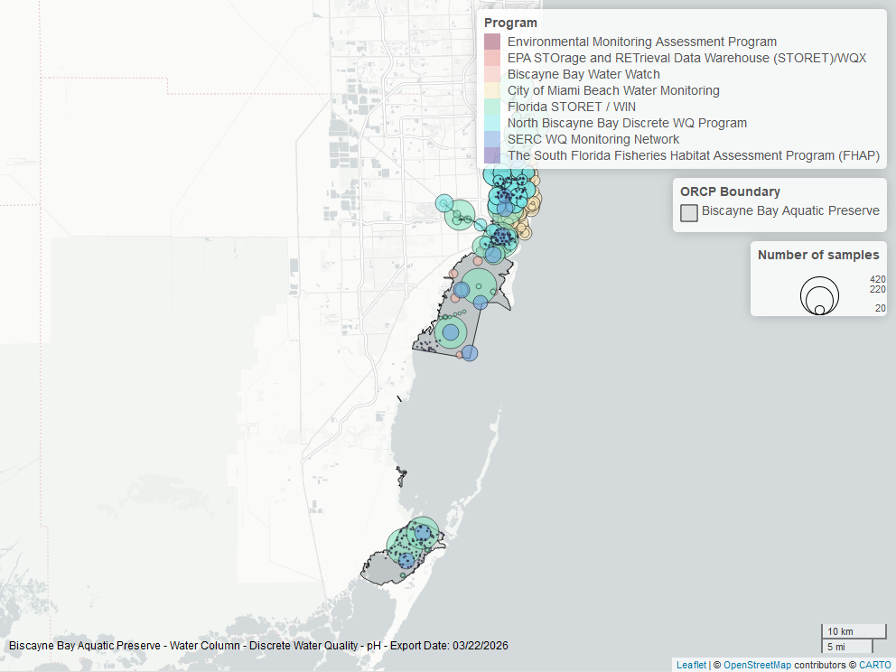

Map showing location of discrete water quality sampling locations within the boundaries of *Biscayne Bay Aquatic Preserve*. The bubble size on the maps above reflect the amount of data available at each sampling site.

### Specific Conductivity - Continuous

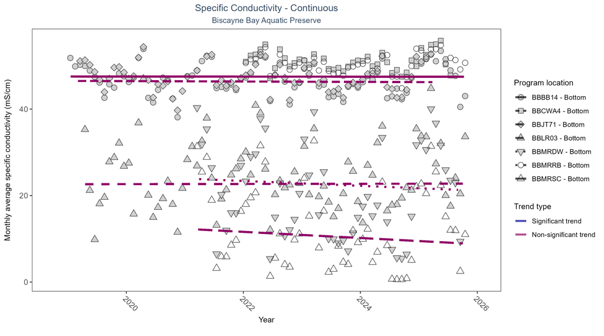

Seasonal Kendall-Tau Results - Specific Conductivity

| Program Location | Statistical Trend | Sample Count | Years with Data | Period of Record | Median Result Value | Tau | Sen Intercept | Sen Slope | P |
| --- | --- | --- | --- | --- | --- | --- | --- | --- | --- |
| BBBB14 | No significant trend | 199381 | 7 | 2019 - 2025 | 47.11 | -0.02 | 47.54 | -0.01 | 0.854 |
| BBCWA4 | Insufficient data to calculate trend | 106556 | 4 | 2022 - 2025 | 51.22 | - | - | - | - |
| BBJT71 | No significant trend | 193275 | 7 | 2019 - 2025 | 47.63 | -0.01 | 46.51 | -0.05 | 0.9563 |
| BBLR03 | No significant trend | 199348 | 7 | 2019 - 2025 | 28.44 | 0.01 | 22.63 | 0.02 | 1 |
| BBMRDW | No significant trend | 146990 | 5 | 2021 - 2025 | 18.45 | -0.17 | 23.94 | -0.56 | 0.2357 |
| BBMRRB | Insufficient data to calculate trend | 124795 | 4 | 2022 - 2025 | 50.80 | - | - | - | - |
| BBMRSC | No significant trend | 154166 | 5 | 2021 - 2025 | 8.98 | -0.09 | 12.32 | -0.71 | 0.4875 |

No detectable change in monthly average specific conductivity was observed at five locations. There was insufficient data to fit a model for two locations.

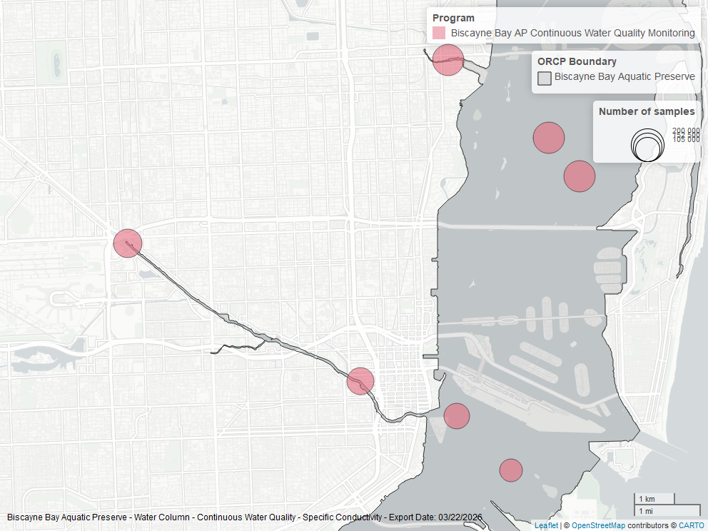

Map showing location of specific conductivity continuous water quality sampling locations within the boundaries of *Biscayne Bay Aquatic Preserve*. The bubble size on the maps above reflect the amount of data available at each sampling site.

## Water Clarity

### Turbidity - Continuous

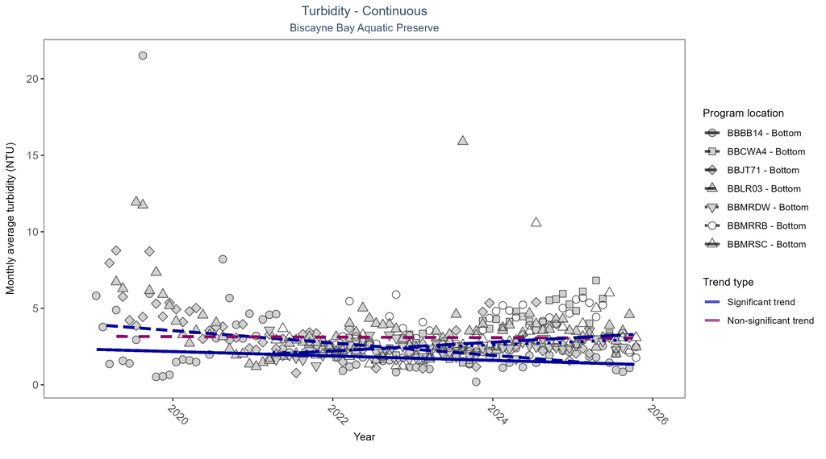

Scatter plot of monthly average turbidity over time at continuously monitored program locations. Each location is analyzed separately, with significant (blue) or non-significant (magenta) trend lines shown for time series that included five or more years of observations.

Seasonal Kendall-Tau Results - Turbidity

| Program Location | Statistical Trend | Sample Count | Years with Data | Period of Record | Median Result Value | Tau | Sen Intercept | Sen Slope | P |
| --- | --- | --- | --- | --- | --- | --- | --- | --- | --- |
| BBBB14 | Significantly decreasing trend | 195719 | 7 | 2019 - 2025 | 2 | -0.22 | 2.32 | -0.14 | 0.0184 |
| BBCWA4 | Insufficient data to calculate trend | 109259 | 4 | 2022 - 2025 | 3 | - | - | - | - |
| BBJT71 | Significantly decreasing trend | 201128 | 7 | 2019 - 2025 | 3 | -0.46 | 3.94 | -0.4 | 0 |
| BBLR03 | No significant trend | 202449 | 7 | 2019 - 2025 | 3 | -0.01 | 3.16 | -0.02 | 0.8108 |
| BBMRDW | Significantly increasing trend | 147146 | 5 | 2021 - 2025 | 2 | 0.35 | 2.04 | 0.19 | 0.0091 |
| BBMRRB | Insufficient data to calculate trend | 123415 | 4 | 2022 - 2025 | 3 | - | - | - | - |
| BBMRSC | Significantly increasing trend | 140544 | 5 | 2021 - 2025 | 2 | 0.41 | 1.92 | 0.29 | 0.002 |

At two program locations, monthly average turbidity increased by 0.19 NTU per year at one site and by 0.29 NTU per year at the other. At two program locations, monthly average turbidity decreased by 0.14 NTU per year at one site and by 0.4 NTU per year at the other. No detectable change in monthly average turbidity was observed at one location. There was insufficient data to fit a model for two locations.

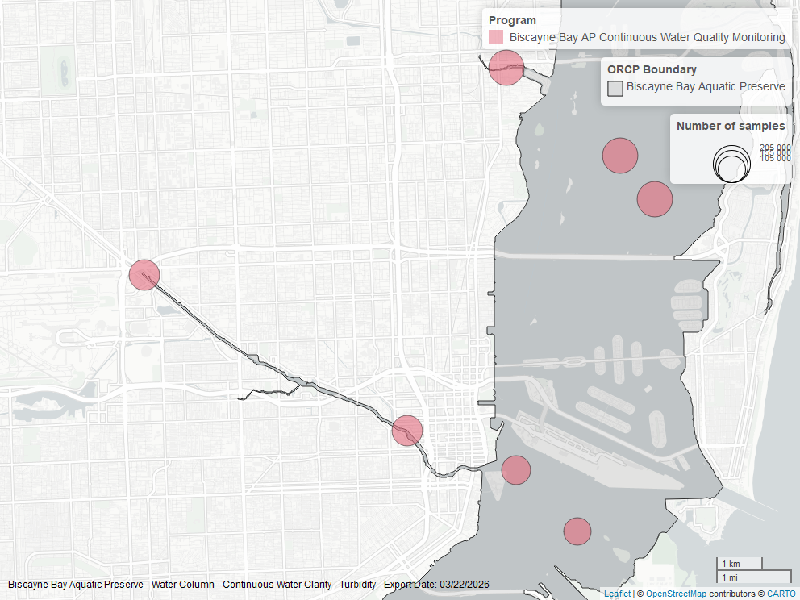

Map showing location of turbidity continuous water quality sampling locations within the boundaries of *Biscayne Bay Aquatic Preserve*. The bubble size on the maps above reflect the amount of data available at each sampling site.

### Turbidity - Discrete

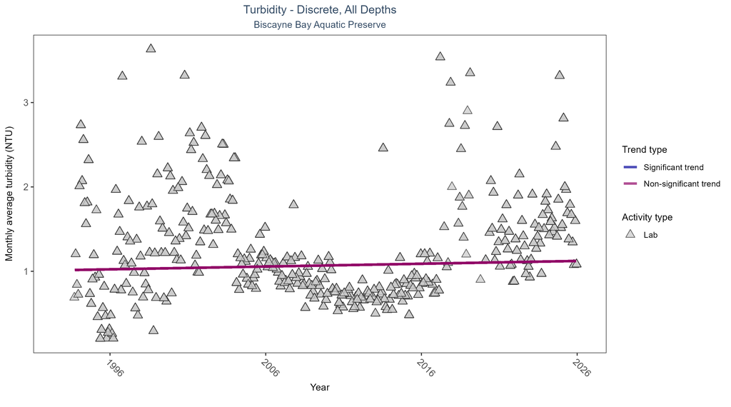

Scatter plot of monthly average turbidity over time. If the time series included ten or more years of discrete observations, a significant (blue) or non-significant (magenta) trend line is also shown. Only turbidity values measured in the laboratory (triangles) are included in the plot.

Seasonal Kendall-Tau Results for - Turbidity

| Activity Type | Statistical Trend | Sample Count | Years with Data | Period of Record | Median Result Value | Tau | Sen Intercept | Sen Slope | P |
| --- | --- | --- | --- | --- | --- | --- | --- | --- | --- |
| Lab | No significant trend | 13958 | 33 | 1993 - 2025 | 0.9 | 0.03996 | 1.01324 | 0.00331 | 0.2562 |

Turbidity showed no detectable trend between 1993 and 2025.

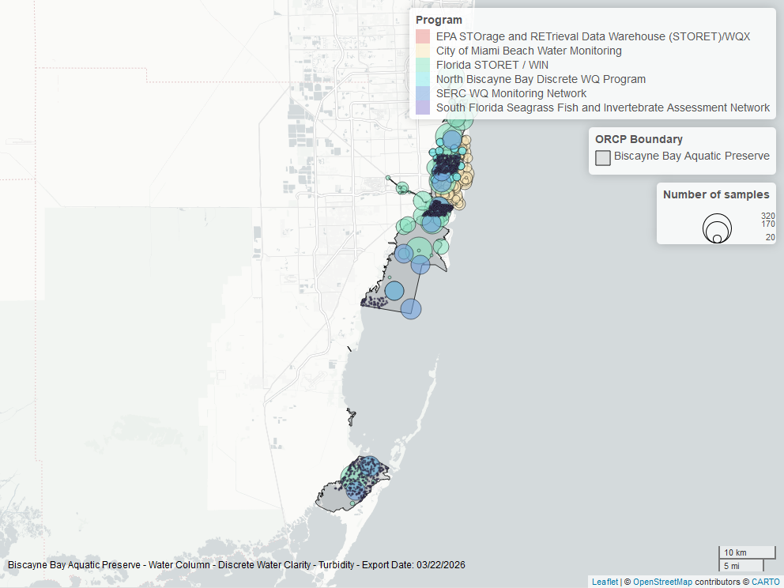

Map showing location of discrete water quality sampling locations within the boundaries of *Biscayne Bay Aquatic Preserve*. The bubble size on the maps above reflect the amount of data available at each sampling site.

### Total Suspended Solids - Discrete

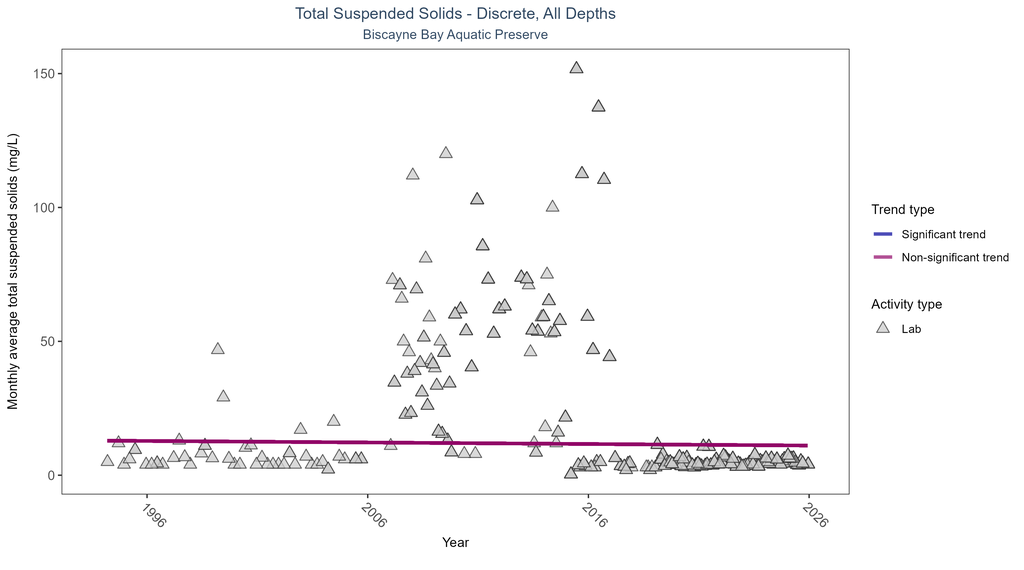

Scatter plot of monthly average total suspended solids (TSS) over time. If the time series included ten or more years of discrete observations, a significant (blue) or non-significant (magenta) trend line is also shown. Only TSS values obtained from laboratory analyses (triangles) are included in the plot.

Seasonal Kendall-Tau Results for - Total Suspended Solids

| Activity Type | Statistical Trend | Sample Count | Years with Data | Period of Record | Median Result Value | Tau | Sen Intercept | Sen Slope | P |
| --- | --- | --- | --- | --- | --- | --- | --- | --- | --- |
| Lab | No significant trend | 2900 | 31 | 1994 - 2025 | 5 | -0.14792 | 12.91189 | -0.05705 | 0.1201 |

Total suspended solids showed no detectable trend between 1994 and 2025.

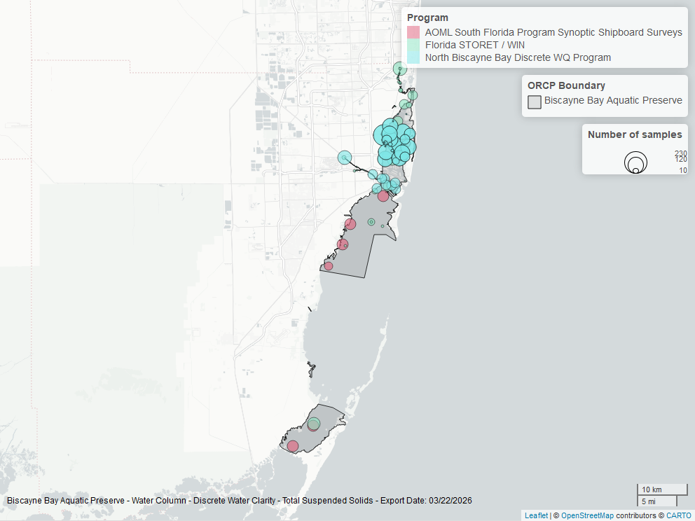

Map showing location of discrete water quality sampling locations within the boundaries of *Biscayne Bay Aquatic Preserve*. The bubble size on the maps above reflect the amount of data available at each sampling site.

### Chlorophyll a, Uncorrected for Pheophytin - Discrete

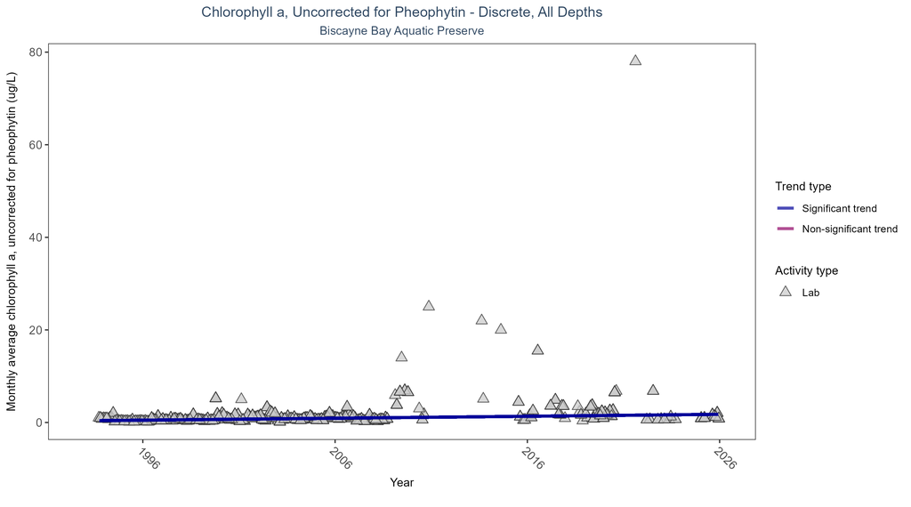

Scatter plot of monthly average levels of chlorophyll a, uncorrected for pheophytin, over time. If the time series included ten or more years of discrete observations, a significant (blue) or non-significant (magenta) trend line is also shown. Only laboratory-analyzed chlorophyll a (triangles) is included in the plot.

Seasonal Kendall-Tau Results for - Chlorophyll a, Uncorrected for Pheophytin

| Activity Type | Statistical Trend | Sample Count | Years with Data | Period of Record | Median Result Value | Tau | Sen Intercept | Sen Slope | P |
| --- | --- | --- | --- | --- | --- | --- | --- | --- | --- |
| Lab | Significantly increasing trend | 2517 | 30 | 1993 - 2025 | 0.70231 | 0.37392 | 0.37401 | 0.04208 | 0 |

Monthly average chlorophyll a, uncorrected for pheophytin, increased by 0.04 µg/L per year, indicating a decrease in water clarity.

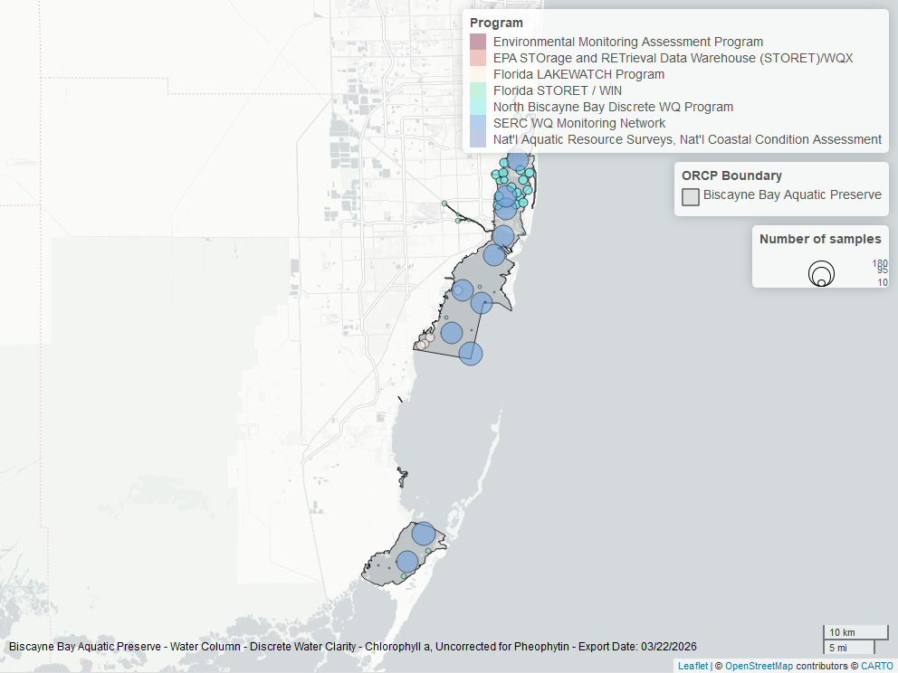

Map showing location of discrete water quality sampling locations within the boundaries of *Biscayne Bay Aquatic Preserve*. The bubble size on the maps above reflect the amount of data available at each sampling site.

### Chlorophyll a, Corrected for Pheophytin - Discrete

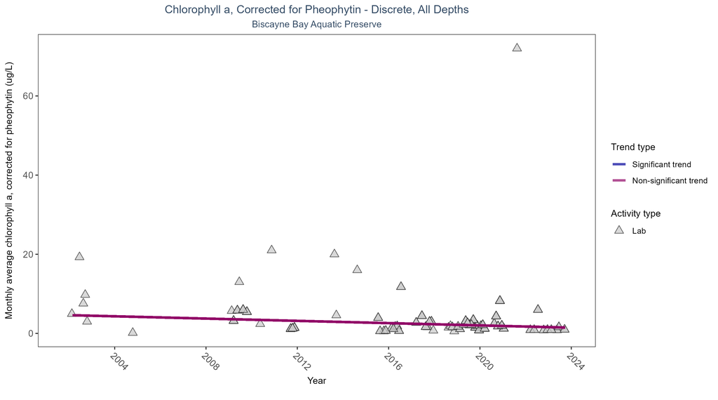

Scatter plot of monthly average levels of chlorophyll a, corrected for pheophytin, over time. If the time series included ten or more years of discrete observations, a significant (blue) or non-significant (magenta) trend line is also shown. Only laboratory-analyzed chlorophyll a (triangles) is included in the plot.

Seasonal Kendall-Tau Results for - Chlorophyll a, Corrected for Pheophytin

| Activity Type | Statistical Trend | Sample Count | Years with Data | Period of Record | Median Result Value | Tau | Sen Intercept | Sen Slope | P |
| --- | --- | --- | --- | --- | --- | --- | --- | --- | --- |
| Lab | No significant trend | 492 | 16 | 2002 - 2023 | 1.4 | -0.20161 | 4.61564 | -0.14393 | 0.0505 |

Chlorophyll a, corrected for pheophytin, showed no detectable trend between 2002 and 2023.

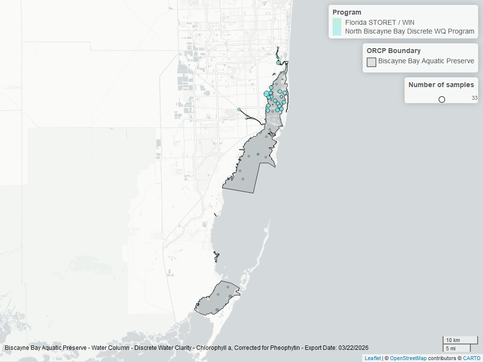

Map showing location of discrete water quality sampling locations within the boundaries of *Biscayne Bay Aquatic Preserve*. The bubble size on the maps above reflect the amount of data available at each sampling site.

### Secchi Depth - Discrete

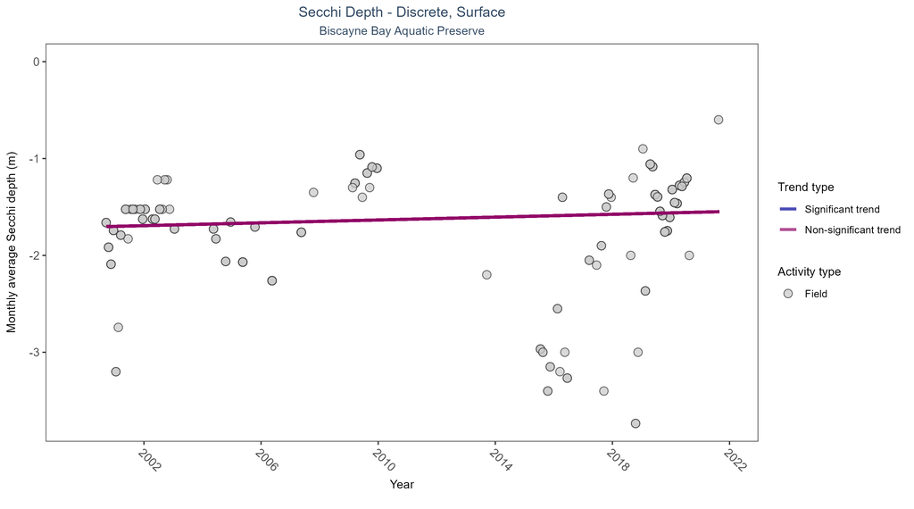

Scatter plot of monthly average Secchi depth over time. If the time series included ten or more years of discrete observations, a significant (blue) or non-significant (magenta) trend line is also shown. Secchi depth is only measured in the field (circles).

Seasonal Kendall-Tau Results for - Secchi Depth

| Activity Type | Statistical Trend | Sample Count | Years with Data | Period of Record | Median Result Value | Tau | Sen Intercept | Sen Slope | P |
| --- | --- | --- | --- | --- | --- | --- | --- | --- | --- |
| Field | No significant trend | 550 | 17 | 2000 - 2021 | -1.45 | 0.14531 | -1.70768 | 0.00733 | 0.4217 |

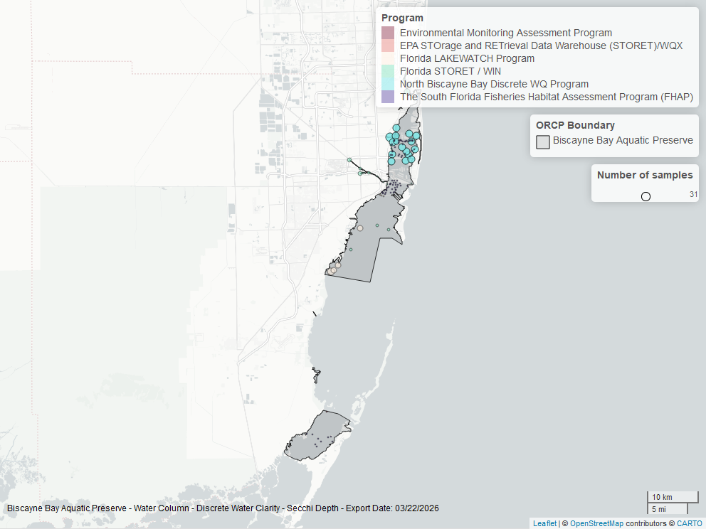

Map showing location of discrete water quality sampling locations within the boundaries of *Biscayne Bay Aquatic Preserve*. The bubble size on the maps above reflect the amount of data available at each sampling site.

### Colored Dissolved Organic Matter - Discrete

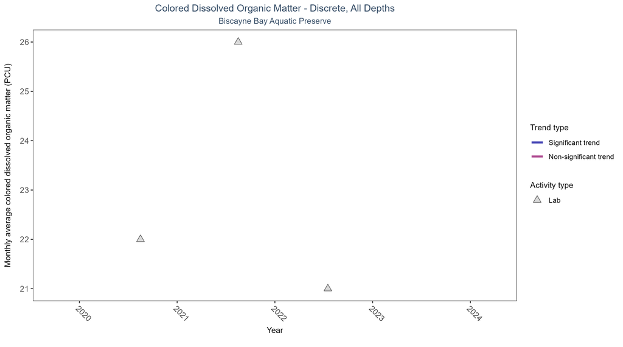

Scatter plot of monthly average colored dissolved organic matter (CDOM) over time. If the time series included ten or more years of discrete observations, a significant (blue) or non-significant (magenta) trend line is also shown. Only laboratory-analyzed CDOM (triangles) is included in the plot.

Seasonal Kendall-Tau Results for - Colored Dissolved Organic Matter

| Activity Type | Statistical Trend | Sample Count | Years with Data | Period of Record | Median Result Value | Tau | Sen Intercept | Sen Slope | P |
| --- | --- | --- | --- | --- | --- | --- | --- | --- | --- |
| Lab | Insufficient data to calculate trend | 3 | 3 | 2020 - 2022 | 22 | - | - | - | - |

There was insufficient data to fit a model for colored dissolved organic matter.

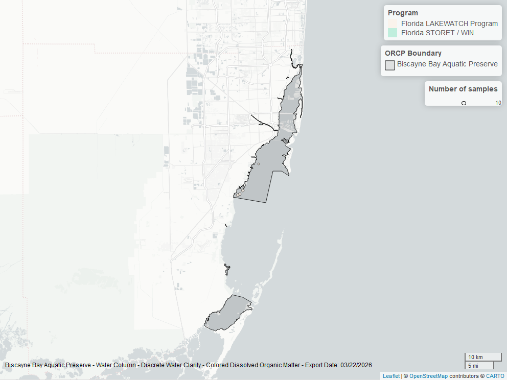

Map showing location of discrete water quality sampling locations within the boundaries of *Biscayne Bay Aquatic Preserve*. The bubble size on the maps above reflect the amount of data available at each sampling site.